# Sesión 2: introducción a R

Estadística para lingüistas

Alejandro Correa | Instituto Caro y Cuervo, Maestría en Lingüística

- Aprender los elementos básicos de la *sintaxis* de R
- Aprender a usar *vectores* y tablas en R
- Aprender a abrir *tablas* y guardarlas en R
- Aprender a buscar información en R usando *operadores lógicos*

# Características de R

- Es un *entorno de programación* (elaborar análisis, desarrollar aplicaciones y programas).
- Permite la aplicación de técnicas de análisis estadístico.
- Figuras para representar datos con alta calidad y una amplia gama de colores.
- Tiene una distribución gratuita.
- Tiene una amplia comunidad de usuarios que actualiza el programa, comparte código, publica libros, etcétera.
- Hay un vasta bibliografía sobre R y su uso en la investigación lingüística.

# Operaciones básicas

## Paquetes

```r
install.packages("languageR"); install.packages("lattice");
install.packages("ggplot2")
```

```r
library(languageR); library(lattice);
library(ggplot2)
```

## Obtener ayuda

```r
help(package = "languageR")
```

```r
help.search("binomial distribution")
```

```
## starting httpd help server ... done
```

```r
?mean
```

# R como una calculadora

```r
2 + 2 #suma
```

```
## [1] 4
```

```r
218 - 7 #resta
```

```
## [1] 211
```

```r
10*2 # multiplicación
```

```
## [1] 20
```

```r
10/2 # división
```

```
## [1] 5
```

# Operaciones aritméticas

```r
4^2 # calcula 4 a la potencia de 2
```

```
## [1] 16
```

```r
16 ^(1/2) #calcula la raíz cuadrada de 16
```

```
## [1] 4
```

```r
(459 + 51) / 3 # Suma 51 a 459 y divide el resultado por 3.
```

```
## [1] 170
```

```r
459 + (51 / 3) # Suma 459 al resultado de dividir 51 por 3.
```

```
## [1] 476
```

# Asignación de variables

Para definir los valores de una variable podemos usar el operador `<-` o el signo igual `=`

```r
a <- (459+51)/3
```

```r
b= 459+ (51)/3
```

```r
a ; b
```

```
## [1] 170
```

```
## [1] 476
```

```r
a + b
```

```
## [1] 646
```

# Funciones y argumentos

### Funciones

Las funciones sirven para realizar tareas (operaciones, mediciones o análisis) específicas. Por ejemplo, la **`sample`** que sirve para generar números aleatoria o pseudoaleatoriamente:

### Argumentos

- `x`: una estructura de datos (un vector) con los elementos que se desean muestrear
- `size`: el tamaño de la muestra
- `replace`: si se asigna el argumento `replace = FALSE` cada elemento del vector se puede muestrear una vez (opción por defecto), pero si el argumento es `replace = TRUE`, los elementos se pueden muestrear varias veces.
- `prob`: la probabilidad de aparición de los elementos del vector. El valor por defecto es `NULL`, lo cual significa que todos los elementos tienen la misma probabilidad.

(Gries, 2013, p.62)

# Función `sample`

Creamos un vector con 10 elementos:

```r
some.data <- c(1:10) # or some.data
```

Se generan 5 elementos con la misma probalilidad:

```r
sample(x=some.data, size=5, replace=TRUE, prob=NULL)
```

```
## [1] 8 9 1 8 9
```

Ahora cada elemento puede aparecer una sola vez:

```r
sample(some.data, 5, FALSE)
```

```
## [1] 4 9 3 2 7
```

# Vectores

Vectores numéricos

```r
números <- c(1, 2, 3); números
```

```
## [1] 1 2 3
```

Vectores de caracteres (nótese el uso del `;` en estos ejemplos):

```r
tres.nombres <- c("Camilo", "Andrés", "Pedro")
```

```r
tres.nombres
```

```
## [1] "Camilo" "Andrés" "Pedro"
```

# Combinar vectores

Es posible crear dos vectores y luego combinarlos

```r
números1 <- c(1, 2, 3); números2 <- c(4, 5, 6)
números.y.números2 <- c(números1,números2) # concatena dos vectores
números.y.números2
```

```
## [1] 1 2 3 4 5 6
```

Lo mismo puede realizarse con la función `append`:

```r
números.y.números2 <- append(números1,números2) # concatena dos vectores
números.y.números2
```

```
## [1] 1 2 3 4 5 6
```

# Trabajando con vectores

Creamos un vector x con la función *concatenate*:

```r
x <- c("a", "b", "c", "d", "e")
print(x)
```

```
## [1] "a" "b" "c" "d" "e"
```

Extraer un elemento:

```r
x[3]
```

```
## [1] "c"
```

# Extraer elementos

Creamos el vector `y` y extraemos el elemento `y` del vector `x`:

```r
y <- 3; x[y]
```

```
## [1] "c"
```

Creamos el vector `z` con 1 y 3 y extraemos los elementos de `z` del vector `x`:

```r
z <- c(1, 3); x[z]
```

```
## [1] "a" "c"
```

Creamos el vector `z` con 1, 2 y 3 y extraemos los elementos de `z` del vector `x`:

```r
z <- c(1:3); x[z]
```

```
## [1] "a" "b" "c"
```

# Vectores y expresiones lógicas I

- Crear un vector que inicie en 10 y termine en 1

```r
x <- c(10:1)
print(x)
```

```
##  [1] 10  9  8  7  6  5  4  3  2  1
```

Los elementos del vector `x` que equivalen a `4`:

```r
x==4
```

```
##  [1] FALSE FALSE FALSE FALSE FALSE FALSE  TRUE FALSE FALSE FALSE
```

Los elementos del vector `x` menor o igual a `7`:

```r
x<=7
```

```
##  [1] FALSE FALSE FALSE  TRUE  TRUE  TRUE  TRUE  TRUE  TRUE  TRUE
```

# Vectores y expresiones lógicas II

Los elementos del vector `x` que no son iguales a `8`:

```r
x!=8 # which elements of x are not 8
```

```
##  [1]  TRUE  TRUE FALSE  TRUE  TRUE  TRUE  TRUE  TRUE  TRUE  TRUE
```

```r
(x>8 | x<3) # which elements of x are >8 or <3
```

```
##  [1]  TRUE  TRUE FALSE FALSE FALSE FALSE FALSE FALSE  TRUE  TRUE
```

Elementos que equivalen a 4:

```r
sum(x==4) # how many elements in x are 4
```

```
## [1] 1
```

# Vectores y expresiones lógicas III

Elementos del vector `x` mayores a 8 o menores a 3:

```r
sum(x>8 | x<3)
```

```
## [1] 4
```

Cuántos elementos del vector x son mayores a 8 o menores a 3:

```r
table(x>8 | x<3)
```

```
##
## FALSE  TRUE
##     6     4
```

En qué posición del vector x se encuentran los elementos igual a 4:

```r
which(x==4)
```

```
## [1] 7
```

En qué posición del vector x se encuentran los elementos que igual o menores a 7:

```r
x;
```

```
##  [1] 10  9  8  7  6  5  4  3  2  1
```

```r
which(x<=7)
```

```
## [1]  4  5  6  7  8  9 10
```

En qué posición del vector x se encuentran los elementos diferentes a 8

```r
x;
```

```
##  [1] 10  9  8  7  6  5  4  3  2  1
```

```r
which(x!=8)
```

```
## [1]  1  2  4  5  6  7  8  9 10
```

Borrar memoria

```r
rm(list=ls(all=TRUE)) #<<
```

# Abrir tabla manualmente

Identificar una carpeta en el PC:

```r
choose.files() #PC
```

Identificar una carpeta en una Mac:

```r
file.choose() #Mac y otros
```

Abrir archivo en tabulaciones:

```r
tabla1<-read.table(file.choose(), header=TRUE)
```

Abrir archivos `csv`:

```r
tabla1<-read.csv(file.choose(), header=TRUE)
```

# Abrir la tabla desde el archivo de origen:

```r
nombretabla<-read.table("...", header= T)
```

```r
tabla1<-read.table("/Users/scien/OneDrive/Clases/EstadísticaparaLingüistas/2025/tablas/nombres.txt", header= T)
```

```r
head(tabla1)
```

|  | name | nickname | gender | nameSyls | nicknameSyls |
| --- | --- | --- | --- | --- | --- |
| 1 | Albert | Al | male | 2 | 1 |
| 2 | Andrew | Andy | male | 2 | 2 |
| 3 | Anthony | Tony | male | 3 | 2 |
| 4 | Arthur | Art | male | 2 | 1 |
| 5 | Arthur | Arty | male | 2 | 2 |
| 6 | Bernard | Bernie | male | 2 | 2 |

# Resumen de la tabla

```r
str(tabla1)
```

```
## 'data.frame':    91 obs. of  5 variables:
##  $ name        : chr  "Albert" "Andrew" "Anthony" "Arthur" ...
##  $ nickname    : chr  "Al" "Andy" "Tony" "Art" ...
##  $ gender      : chr  "male" "male" "male" "male" ...
##  $ nameSyls    : int  2 2 3 2 2 2 2 1 1 3 ...
##  $ nicknameSyls: int  1 2 2 1 2 2 1 2 1 1 ...
```

```r
summary(tabla1)
```

```
##      name             nickname            gender             nameSyls
##  Length:91          Length:91          Length:91          Min.   :1.000
##  Class :character   Class :character   Class :character   1st Qu.:2.000
##  Mode  :character   Mode  :character   Mode  :character   Median :2.000
##                                                           Mean   :2.308
##                                                           3rd Qu.:3.000
##                                                           Max.   :4.000
##   nicknameSyls
##  Min.   :1.000
##  1st Qu.:1.000
##  Median :1.000
##  Mean   :1.385
##  3rd Qu.:2.000
##  Max.   :2.000
```

# Búsqueda de filas y columnas

# Buscando casos (fila y columna)

```r
tabla1[1,2]
```

```
## [1] "Al"
```

```r
tabla1[1,]
```

|  | name | nickname | gender | nameSyls | nicknameSyls |
| --- | --- | --- | --- | --- | --- |
| 1 | Albert | Al | male | 2 | 1 |

```r
tabla1[1,1]
```

```
## [1] "Albert"
```

```r
tabla1[,1]
```

```
##  [1] "Albert"      "Andrew"      "Anthony"     "Arthur"      "Arthur"
##  [6] "Bernard"     "Bernard"     "Charles"     "Charles"     "Christopher"
## [11] "Daniel"      "Daniel"      "Donald"      "Edward"      "Edward"
## [16] "Eugene"      "Francis"     "Francis"     "Frederick"   "Frederick"
## [21] "Henry"       "Irving"      "James"       "James"       "John"
## [26] "John"        "Joseph"      "Lawrence"    "Leonard"     "Nathan"
## [31] "Nathan"      "Nicholas"    "Patrick"     "Peter"       "Raymond"
## [36] "Richard"     "Richard"     "Robert"      "Robert"      "Robert"
## [41] "Ronald"      "Ronald"      "Russell"     "Samuel"      "Samuel"
## [46] "Stephan"     "Stuart"      "Theodore"    "Theodore"    "Thomas"
## [51] "Thomas"      "Thomas"      "Timothy"     "Timothy"     "Walter"
## [56] "Walter"      "William"     "William"     "William"     "William"
## [61] "Amanda"      "Catherine"   "Catherine"   "Christine"   "Christine"
## [66] "Cynthia"     "Cynthia"     "Deborah"     "Deborah"     "Elizabeth"
## [71] "Elizabeth"   "Elizabeth"   "Elizabeth"   "Florence"    "Frances"
## [76] "Frances"     "Janet"       "Janice"      "Katherine"   "Katherine"
## [81] "Nancy"       "Pamela"      "Patricia"    "Roberta"     "Sophia"
## [86] "Susan"       "Susan"       "Teresa"      "Valerie"     "Veronica"
## [91] "Yvonne"
```

```r
tabla1[c(24, 32, 67, 75, 23, 91),]
```

|  | name | nickname | gender | nameSyls | nicknameSyls |
| --- | --- | --- | --- | --- | --- |
| 24 | James | Jimmy | male | 1 | 2 |
| 32 | Nicholas | Nick | male | 3 | 1 |
| 67 | Cynthia | Cynth | female | 3 | 1 |
| 75 | Frances | Fran | female | 2 | 1 |
| 23 | James | Jim | male | 1 | 1 |
| 91 | Yvonne | Vonna | female | 2 | 2 |

```r
nombres<- c("James", "Nicholas","Cynthia", "Frances","James", "Yvonne")
```

```r
silabas<- c(1,3,3,2,1,2)
```

```r
names(silabas)= nombres
```

### Barplot (diagrama de barras)

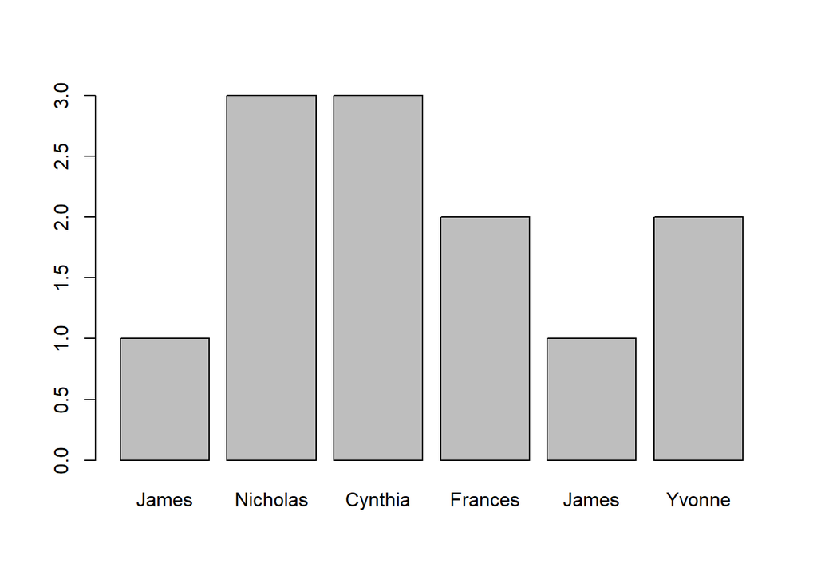

```r
barplot(silabas)
```

### Diagrama de barras con rótulos

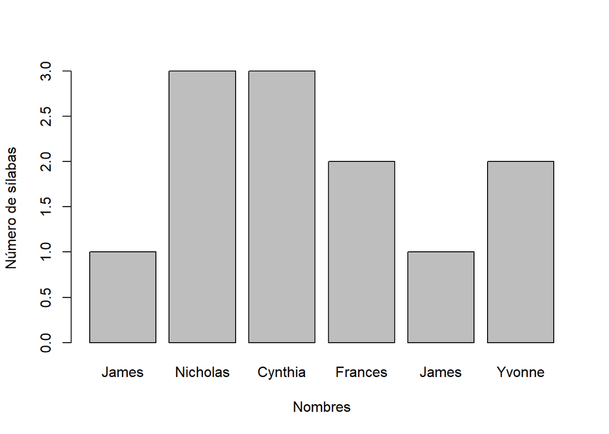

```r
barplot(silabas, xlab="Nombres", ylab="Número de sílabas")
```

# Bibliografía 📚

El código y las tablas se basa en:

1. Gries, Stefan. 2013. *Statistic for linguistics with R. A practical introduction*. Berlin: Mouton de Gruyter.
2. Levshina, Natalia. 2015. *How to Do Linguistics with R: Data exploration and statistical analysis*. Amsterdam: John Benjamins. Capítulo 2, pp. 21-40.
3. Smith, Bridget J., Beckman, Mary E., and Foltz, Anouschka (2016). *Analyzing the sounds of languages*. Ohio State University. Tabla 1, y capítulo 0. Recuperado de: [http://hdl.handle.net/1811/77848]